# POLS3003: Data Science and Big Data Analysis

[output not shown]

**Course Code:** POLS3003

**Course Tutor:** [Dr Slava Mikhaylov](https://www.ucl.ac.uk/spp/people/academic/slava-mikhaylov) *(Department of Political Science)*

**Length:** One term (Spring Term)

**Teaching:** 20 hours lectures/seminars

**Assessment:** Two 2,000 word essays (40/60%)

**Credits:** 0.5 course units, 4 (US) 7.5 (ECTS)

**Module Level:** Advanced

#### About this course

Data Science and Big Data Analytics are exciting new areas that combine scientific inquiry, substantive expertise, programming, and statistical knowledge. One of the main challenges for businesses and policy makers when using big data is to find people with the appropriate skills. Data Science is no longer only the domain of computer scientists and engineers. Good Data Science requires experts that combine substantive knowledge with data analytical skills, which makes it a prime area for social scientists with an interest in quantitative methods.

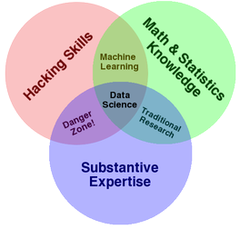

Drew Conway’s Data Science Venn diagram (http://bit.ly/1fDSjpe) highlights the focus of this course. The course integrates prior training in quantitative methods (statistics) and coding with substantive expertise and introduces the fundamental concepts and techniques of Data Science and Big Data Analytics.

**Drew Conway’s Data Science Venn Diagram (Source: http://bit.ly/1fDSjpe)**

**Aims**

This course aims to provide an introduction to the data science approach to the quantitative analysis of data using the methods of statistical learning, an approach blending classical statistical methods with recent advances in computational and machine learning. The course will cover the main analytical methods from this field with hands-on applications using example datasets, so that students gain experience with and confidence in using the methods we cover. It also covers data preparation and processing, including working with structured databases, key-value formatted data (JSON), and unstructured textual data.

**Learning outcomes**

At the end of this course students will have a sound understanding of the field of data science, the ability to analyse data using some of its main methods, and a solid foundation for more advanced or more specialized study.

**Prerequisites**

This is an advanced course intended for students who’ve already had some training in quantitative methods for data analysis. The minimum prerequisite is a good knowledge of linear regression models and familiarity with a statistical software package (e.g., R, Stata, SPSS, SAS, MATLAB).

In order to take the course students must have passed ECON2007 (Quantitative Economics and Econometrics). If you don’t have the required prerequisites or you believe you have taken an equivalent course please contact the course tutor for confirmation.

[output not shown]